# Metrics of Quality Assessment

## Author: Ram Saran Vuppuluri

### Introduction

Kaggle had initiated an industry-wide survey in 2017 that presents a truly comprehensive view of the state of data science and machine learning. In 2018, the study was live for a week in October and had collected responses from 23,859 individuals.

Data set used for the analysis is has 390+ columns. Not all columns are needed at any given point of the study. For this reason, the notebook is further divided into multiple subsections which will start with a business question, followed by data analysis. Only the columns that are related to the business question are extracted for analysis.

Furthermore, we are persisting extracted columns into separate csv files that are utilized for generating visualizations using Tableau for Medium blog post.

**One significant advantage with this approach is we are not ignoring the whole row if the respondent has not to answer specific questions. We are going to include all the answers (non-freeform) in the analysis.**

In this notebook, we will analyze the Metrics of Quality Assessment practiced by survey takers.

```python
import gc

import pandas as pd
import matplotlib.pyplot as plt
import seaborn as sns
%matplotlib inline

import warnings
warnings.filterwarnings('ignore')
```

```python
def generate_vertical_countplot(x, xlabel='', figName=None, figSize=(8, 6)):
    '''
    This method will generate vertical Seaborn countplot.

    :param x: x parameter

    :param xlabel: x axis label

    :param figName: file name by which it need to be stored.

    :param figSize: plot figure size.

    :return: None
    '''
    sns.set(rc={'figure.figsize': figSize})

    ax = sns.countplot(x=x)

    plt.xlabel(xlabel)
    if figName != None:
        ax.get_figure().savefig(figName)
    plt.show(ax);
```

```python
def generate_horizontal_countplot(y, ylabel='', figName=None, figSize=(12, 10)):
    '''
    This method will generate horizontal Seaborn countplot/

    :param y: y parameter

    :param ylabel: y axis label

    :param figName: file name by which it need to be stored

    :param figSize: plot figure size.

    :return: None
    '''
    sns.set(rc={'figure.figsize': figSize})

    ax = sns.countplot(y=y)

    plt.ylabel(ylabel)

    if figName != None:
        ax.get_figure().savefig(figName)
    plt.show(ax);
```

```python
multipleChoiceDF = pd.read_csv('../multipleChoiceResponses.csv',low_memory=False)
```

### Which better demonstrates expertise in data science: academic achievements or independent projects?

```python
independentAcademicDF = pd.DataFrame(multipleChoiceDF.Q40)
```

```python
independentAcademicDF.info()
```

```
<class 'pandas.core.frame.DataFrame'>
RangeIndex: 23860 entries, 0 to 23859
Data columns (total 1 columns):
Q40    15880 non-null object
dtypes: object(1)
memory usage: 186.5+ KB
```

```python
independentAcademicDF.head()
```

|  | Q40 |
| --- | --- |
| 0 | Which better demonstrates expertise in data sc... |
| 1 | Independent projects are equally important as ... |
| 2 | Independent projects are equally important as ... |
| 3 | Independent projects are equally important as ... |
| 4 | Independent projects are much more important t... |

From the visual and programmatic analysis:

- There are rows with missing data, we will not include these records in our report.
- All columns are loaded with the correct data type.
- Row with ID 0, is the same as the question. We will drop this row from the analysis as it does not have any empirical value.
- Column names are not informative, we will rename columns with more informative names.

```python
independentAcademicDF.drop([0],inplace=True)
```

```python
independentAcademicDF.reset_index(drop=True,inplace=True)
```

```python
independentAcademicDF.rename(columns={"Q40":"independentAcademic"},inplace=True)
```

**The academic background for Data Scientists is very diverse, and for this reason, academic success is not always a right scale while hiring a data scientist. Alternatively, analyzing independent projects might be the best way to assess the skill set of potential employees**

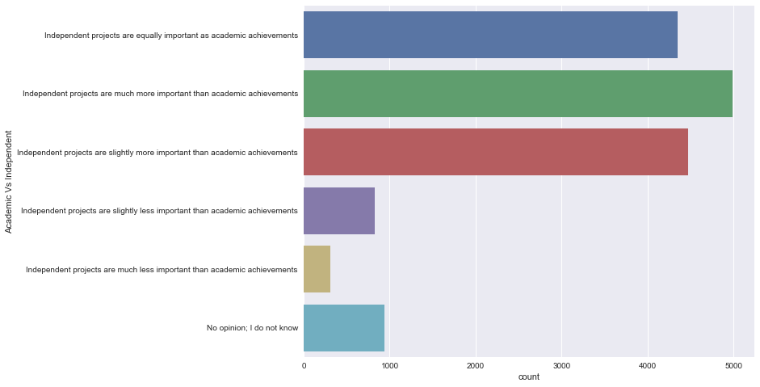

```python
generate_horizontal_countplot(y=independentAcademicDF.independentAcademic,
                             figSize=(10,8),
                             ylabel = 'Academic Vs Independent',
                             figName = 'independentAcademic.jpeg')
```

We will persist the clean copy of the dataframe as a CSV file.

We no longer need "independentAcademicDF" in the analysis. We will clean up from memory.

```python
independentAcademicDF.to_csv('independentAcademic.csv',index=False)
```

```python
del independentAcademicDF
gc.collect()
```

```
2497
```

### How do you perceive the importance of the following topics?

- **Fairness and bias in ML algorithms**
- **Being able to explain ML model outputs and/or predictions**
- **Reproducibility in data science**

```python
importantTopicsDF = multipleChoiceDF[['Q41_Part_1', 'Q41_Part_2','Q41_Part_3']]
```

```python
importantTopicsDF.head()
```

|  | Q41_Part_1 | Q41_Part_2 | Q41_Part_3 |
| --- | --- | --- | --- |
| 0 | How do you perceive the importance of the foll... | How do you perceive the importance of the foll... | How do you perceive the importance of the foll... |
| 1 | NaN | NaN | NaN |
| 2 | NaN | NaN | NaN |
| 3 | Very important | Very important | Very important |
| 4 | Very important | Very important | Very important |

```python
importantTopicsDF.info()
```

```
<class 'pandas.core.frame.DataFrame'>
RangeIndex: 23860 entries, 0 to 23859
Data columns (total 3 columns):
Q41_Part_1    14937 non-null object
Q41_Part_2    14937 non-null object
Q41_Part_3    14937 non-null object
dtypes: object(3)
memory usage: 559.3+ KB
```

From the visual and programmatic analysis:

- There are rows with missing data, we will not include these records in our report.
- All columns are loaded with the correct data type.
- Row with ID 0, is the same as the question. We will drop this row from the analysis as it does not have any empirical value.
- Column names are not informative, we will rename columns with more informative names.

```python
importantTopicsDF.drop([0],inplace=True)
importantTopicsDF.reset_index(drop=True,inplace=True)
```

```python
importantTopicsDF.head()
```

|  | Q41_Part_1 | Q41_Part_2 | Q41_Part_3 |
| --- | --- | --- | --- |
| 0 | NaN | NaN | NaN |
| 1 | NaN | NaN | NaN |
| 2 | Very important | Very important | Very important |
| 3 | Very important | Very important | Very important |
| 4 | Not at all important | Slightly important | Very important |

```python
importantTopicsDF.rename(columns={"Q41_Part_1":"Fairness_Bias",
                                  "Q41_Part_2":"Explain_Model",
                                  "Q41_Part_3":"Reproducibility"},inplace=True)
```

```python
importantTopicsDF.head()
```

|  | Fairness_Bias | Explain_Model | Reproducibility |
| --- | --- | --- | --- |
| 0 | NaN | NaN | NaN |
| 1 | NaN | NaN | NaN |
| 2 | Very important | Very important | Very important |
| 3 | Very important | Very important | Very important |
| 4 | Not at all important | Slightly important | Very important |

**In the survey, respondents were asked how do they rate the importance of Fairness Bias, Reproducibility and explaining the output of the model.**

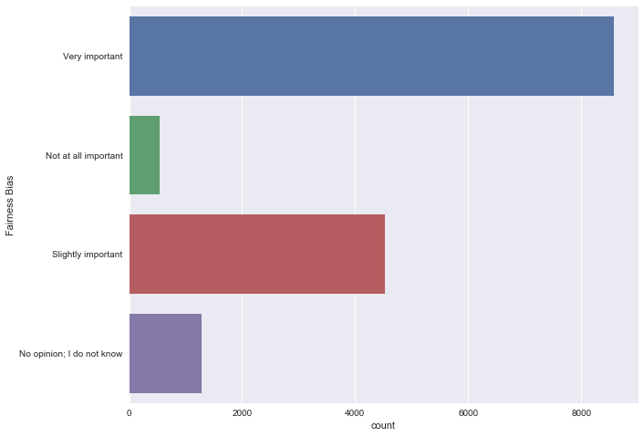

```python
generate_horizontal_countplot(y=importantTopicsDF.Fairness_Bias,
                             figSize=(10,8),
                             ylabel = 'Fairness Bias',
                             figName = 'Fairness_Bias.jpeg')
```

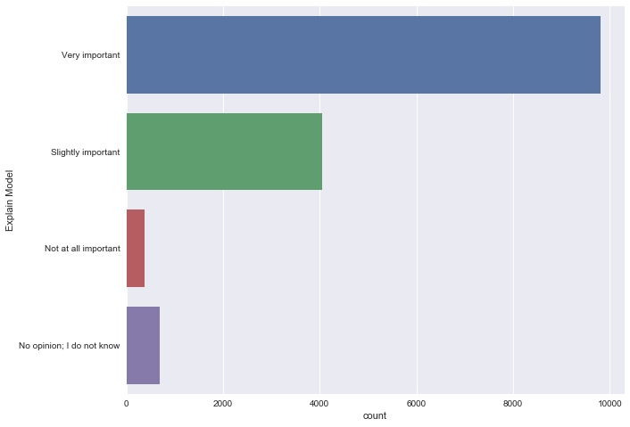

```python
generate_horizontal_countplot(y=importantTopicsDF.Explain_Model,
                             figSize=(10,8),
                             ylabel = 'Explain Model',
                             figName = 'Explain_Model.jpeg')
```

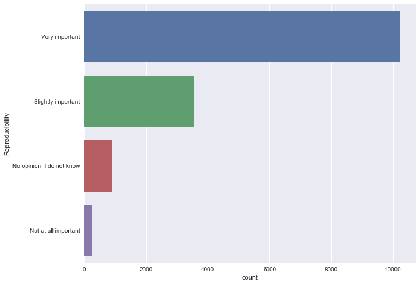

```python
generate_horizontal_countplot(y=importantTopicsDF.Reproducibility,
                             figSize=(10,8),
                             ylabel = 'Reproducibility',
                             figName = 'Reproducibility.jpeg')
```

We will persist the clean copy of the dataframe as a CSV file.

We no longer need "importantTopicsDF" in the analysis. We will clean up from memory.

```python
importantTopicsDF.to_csv('importantTopics.csv',index=False)
```

```python
del importantTopicsDF
gc.collect()
```

```
6656
```

### What metrics do you or your organization use to determine whether or not your models were successful?

- **Revenue and/or business goals**
- **Metrics that consider accuracy**
- **Metrics that consider unfair bias**
- **Not applicable (I am not involved with an organization that builds ML models)**
- **Other**

```python
businessValueDF = multipleChoiceDF[['Q42_Part_1', 'Q42_Part_2','Q42_Part_3', 'Q42_Part_4','Q42_Part_5']]
```

```python
businessValueDF.head()
```

|  | Q42_Part_1 | Q42_Part_2 | Q42_Part_3 | Q42_Part_4 | Q42_Part_5 |
| --- | --- | --- | --- | --- | --- |
| 0 | What metrics do you or your organization use t... | What metrics do you or your organization use t... | What metrics do you or your organization use t... | What metrics do you or your organization use t... | What metrics do you or your organization use t... |
| 1 | NaN | NaN | NaN | NaN | NaN |
| 2 | NaN | NaN | NaN | NaN | NaN |
| 3 | NaN | Metrics that consider accuracy | NaN | NaN | NaN |
| 4 | Revenue and/or business goals | Metrics that consider accuracy | NaN | NaN | NaN |

```python
businessValueDF.info()
```

```
<class 'pandas.core.frame.DataFrame'>
RangeIndex: 23860 entries, 0 to 23859
Data columns (total 5 columns):
Q42_Part_1    5581 non-null object
Q42_Part_2    8417 non-null object
Q42_Part_3    2794 non-null object
Q42_Part_4    3118 non-null object
Q42_Part_5    292 non-null object
dtypes: object(5)
memory usage: 932.1+ KB
```

From the visual and programmatic analysis:

- There are rows with missing data, but deviating from data we explored till now, missing information is expected per record as selections are optional. We will melt into one single column removing missing values, and use this column for analysis.
- All columns are loaded with the correct data type.
- Row with ID 0, is the same as the question. We will drop this row from the analysis as it does not have any empirical value.
- Column names are not informative, we will rename columns with more informative names.

```python
businessValueDF.drop([0],inplace=True)
businessValueDF.reset_index(drop = True,inplace=True)
```

```python
businessValueDF = pd.melt(businessValueDF)
```

```python
businessValueDF.head()
```

|  | variable | value |
| --- | --- | --- |
| 0 | Q42_Part_1 | NaN |
| 1 | Q42_Part_1 | NaN |
| 2 | Q42_Part_1 | NaN |
| 3 | Q42_Part_1 | Revenue and/or business goals |
| 4 | Q42_Part_1 | NaN |

```python
businessValueDF.drop(columns=['variable'],inplace=True)
businessValueDF.dropna(inplace=True)
businessValueDF.reset_index(drop=True,inplace=True)
```

```python
businessValueDF.rename(columns={'value':'business_value'},inplace=True)
```

**Each business has its own metric for measuring the successful implementation of machine learning. For the majority of businesses, accuracy is the key driving factor to implement ML along with Revenue and Business Goals.**

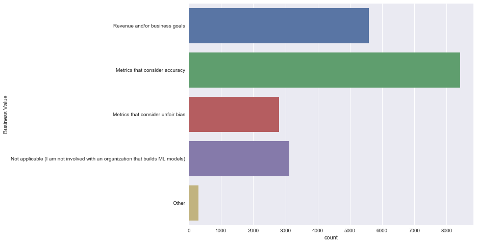

```python
generate_horizontal_countplot(y=businessValueDF.business_value,
                             figSize=(10,8),
                             ylabel = 'Business Value',
                             figName = 'business_value.jpeg')
```

We will persist the clean copy of the dataframe as a CSV file.

We no longer need "businessValueDF" in the analysis. We will clean up from memory.

```python
businessValueDF.to_csv('businessValue.csv',index=False)
```

```python
del businessValueDF
gc.collect()
```

```
2570
```

### Approximately what percent of your data projects involved exploring unfair bias in the dataset and/or algorithm?

```python
exploringUnbiasDF = pd.DataFrame(multipleChoiceDF.Q43)
```

```python
exploringUnbiasDF.head()
```

|  | Q43 |
| --- | --- |
| 0 | Approximately what percent of your data projec... |
| 1 | NaN |
| 2 | NaN |
| 3 | 0-10 |
| 4 | 0-10 |

```python
exploringUnbiasDF.info()
```

```
<class 'pandas.core.frame.DataFrame'>
RangeIndex: 23860 entries, 0 to 23859
Data columns (total 1 columns):
Q43    13120 non-null object
dtypes: object(1)
memory usage: 186.5+ KB
```

From the visual and programmatic analysis:

- There are rows with missing data, we will not include these records in our report.
- All columns are loaded with the correct data type.
- Row with ID 0, is the same as the question. We will drop this row from the analysis as it does not have any empirical value.
- Column names are not informative, we will rename columns with more informative names.

```python
exploringUnbiasDF.drop([0],inplace=True)
exploringUnbiasDF.dropna(inplace=True)
exploringUnbiasDF.reset_index(drop=True,inplace=True)
```

```python
exploringUnbiasDF.rename(columns={"Q43":"exploringUnbias"},inplace=True)
```

**Finding unbiased data is always a challenge. The good thing is that most of the Data Scientists are aware of the problem and the sad thing is that not a lot of Data Scientists are investing time to mitigate bias.**

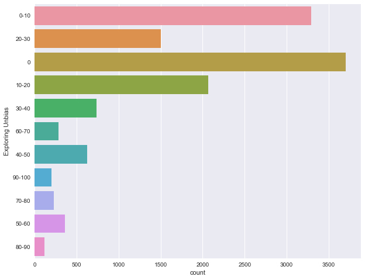

```python
generate_horizontal_countplot(y=exploringUnbiasDF.exploringUnbias,
                             figSize=(10,8),
                             ylabel = 'Exploring Unbias',
                             figName = 'exploringUnbias.jpeg')
```

We will persist the clean copy of the dataframe as a CSV file.

```python
exploringUnbiasDF.to_csv('exploringUnbias.csv',index=False)
```

```python
del exploringUnbiasDF
gc.collect()
```

```
3165
```

### What do you find most difficult about ensuring that your algorithms are fair and unbiased?

- **Lack of communication between individuals who collect the data and individuals who analyze the data**
- **Difficulty in identifying groups that are unfairly targeted**
- **Difficulty in collecting enough data about groups that may be unfairly targeted**
- **Difficulty in identifying and selecting the appropriate evaluation metrics**
- **I have never found any difficulty in this task**
- **I have never performed this task**

```python
reasonForBiasDF = multipleChoiceDF[['Q44_Part_1', 'Q44_Part_2','Q44_Part_3', 'Q44_Part_4','Q44_Part_5', 'Q44_Part_6']]
```

```python
reasonForBiasDF.head()
```

|  | Q44_Part_1 | Q44_Part_2 | Q44_Part_3 | Q44_Part_4 | Q44_Part_5 | Q44_Part_6 |
| --- | --- | --- | --- | --- | --- | --- |
| 0 | What do you find most difficult about ensuring... | What do you find most difficult about ensuring... | What do you find most difficult about ensuring... | What do you find most difficult about ensuring... | What do you find most difficult about ensuring... | What do you find most difficult about ensuring... |
| 1 | NaN | NaN | NaN | NaN | NaN | NaN |
| 2 | NaN | NaN | NaN | NaN | NaN | NaN |
| 3 | Lack of communication between individuals who ... | NaN | NaN | NaN | NaN | NaN |
| 4 | NaN | NaN | Difficulty in collecting enough data about gro... | NaN | NaN | NaN |

```python
reasonForBiasDF.info()
```

```
<class 'pandas.core.frame.DataFrame'>
RangeIndex: 23860 entries, 0 to 23859
Data columns (total 6 columns):
Q44_Part_1    3298 non-null object
Q44_Part_2    3705 non-null object
Q44_Part_3    5299 non-null object
Q44_Part_4    4616 non-null object
Q44_Part_5    450 non-null object
Q44_Part_6    4037 non-null object
dtypes: object(6)
memory usage: 1.1+ MB
```

From the visual and programmatic analysis:

- There are rows with missing data, but deviating from data we explored till now, missing information is expected per record as selections are optional. We will melt into one single column removing missing values, and use this column for analysis.
- All columns are loaded with the correct data type.
- Row with ID 0, is the same as the question. We will drop this row from the analysis as it does not have any empirical value.
- Column names are not informative, we will rename columns with more informative names.

```python
reasonForBiasDF.drop([0],inplace=True)
reasonForBiasDF.reset_index(drop=True,inplace=True)
```

```python
reasonForBiasDF = pd.melt(reasonForBiasDF)
```

```python
reasonForBiasDF.head()
```

|  | variable | value |
| --- | --- | --- |
| 0 | Q44_Part_1 | NaN |
| 1 | Q44_Part_1 | NaN |
| 2 | Q44_Part_1 | Lack of communication between individuals who ... |
| 3 | Q44_Part_1 | NaN |
| 4 | Q44_Part_1 | NaN |

```python
reasonForBiasDF.drop(columns=['variable'],inplace=True)
reasonForBiasDF.rename(columns={'value':'reasonForBias'},inplace=True)
reasonForBiasDF.dropna(inplace=True)
reasonForBiasDF.reset_index(drop=True,inplace=True)
```

**Machine Learning models use the input data to make the predictions if the input data itself is biased or not fair, the same is propagated to the model predictions.**

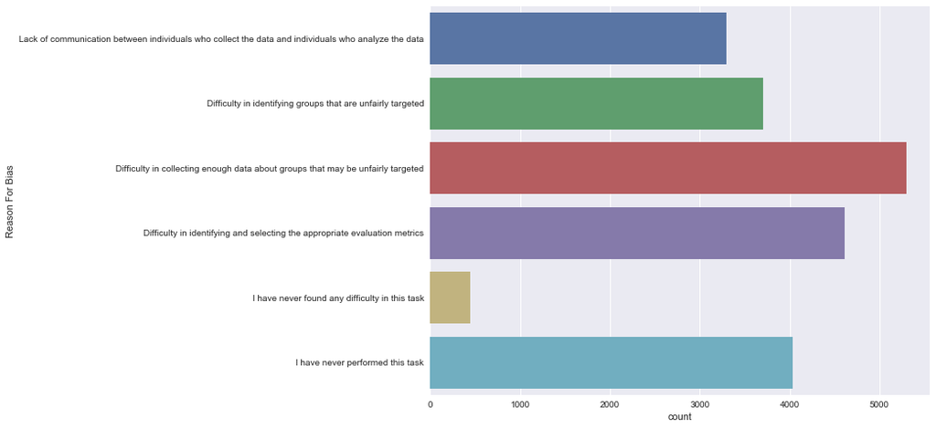

```python
generate_horizontal_countplot(y=reasonForBiasDF.reasonForBias,
                             figSize=(10,8),
                             ylabel = 'Reason For Bias',
                             figName = 'reasonForBias.jpeg')
```

We will persist the clean copy of the dataframe as a CSV file.

We no longer need "reasonForBiasDF" in the analysis. We will clean up from memory.

```python
reasonForBiasDF.to_csv('reasonForBias.csv',index=False)
```

```python
del reasonForBiasDF
gc.collect()
```

```
2478
```

### In what circumstances would you explore model insights and interpret your model's predictions?

- **Only for very important models that are already in production**
- **For all models right before putting the model in production**
- **When determining whether it is worth it to put the model into production**
- **When building a model that was specifically designed to produce such insights**
- **When first exploring a new ML model or dataset**
- **I do not explore and interpret model insights and predictions**

```python
modelInsightsDF = multipleChoiceDF[['Q45_Part_1', 'Q45_Part_2','Q45_Part_3', 'Q45_Part_4','Q45_Part_5', 'Q45_Part_6']]
```

```python
modelInsightsDF.head()
```

|  | Q45_Part_1 | Q45_Part_2 | Q45_Part_3 | Q45_Part_4 | Q45_Part_5 | Q45_Part_6 |
| --- | --- | --- | --- | --- | --- | --- |
| 0 | In what circumstances would you explore model ... | In what circumstances would you explore model ... | In what circumstances would you explore model ... | In what circumstances would you explore model ... | In what circumstances would you explore model ... | In what circumstances would you explore model ... |
| 1 | NaN | NaN | NaN | NaN | NaN | NaN |
| 2 | NaN | NaN | NaN | NaN | NaN | NaN |
| 3 | NaN | NaN | When determining whether it is worth it to put... | NaN | NaN | NaN |
| 4 | NaN | NaN | NaN | When building a model that was specifically de... | NaN | NaN |

```python
modelInsightsDF.info()
```

```
<class 'pandas.core.frame.DataFrame'>
RangeIndex: 23860 entries, 0 to 23859
Data columns (total 6 columns):
Q45_Part_1    1692 non-null object
Q45_Part_2    4739 non-null object
Q45_Part_3    5417 non-null object
Q45_Part_4    5763 non-null object
Q45_Part_5    5575 non-null object
Q45_Part_6    1489 non-null object
dtypes: object(6)
memory usage: 1.1+ MB
```

From the visual and programmatic analysis:

- There are rows with missing data, but deviating from data we explored till now, missing information is expected per record as selections are optional. We will melt into one single column removing missing values, and use this column for analysis.
- All columns are loaded with the correct data type.
- Row with ID 0, is the same as the question. We will drop this row from the analysis as it does not have any empirical value.
- Column names are not informative, we will rename columns with more informative names.

```python
modelInsightsDF.drop([0],inplace=True)
modelInsightsDF.reset_index(drop=True,inplace=True)
```

```python
modelInsightsDF = pd.melt(modelInsightsDF)
```

```python
modelInsightsDF.head()
```

|  | variable | value |
| --- | --- | --- |
| 0 | Q45_Part_1 | NaN |
| 1 | Q45_Part_1 | NaN |
| 2 | Q45_Part_1 | NaN |
| 3 | Q45_Part_1 | NaN |
| 4 | Q45_Part_1 | NaN |

```python
modelInsightsDF.drop(columns=['variable'],inplace=True)
modelInsightsDF.dropna(inplace=True)
modelInsightsDF.reset_index(drop=True,inplace=True)
```

```python
modelInsightsDF.rename(columns={'value':'modelInsights'},inplace=True)
```

**In general, most of the respondents look into the performance in terms of quality of model during development time or while exploring anamolies in the results in production.**

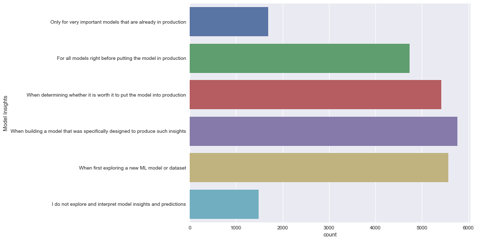

```python
generate_horizontal_countplot(y=modelInsightsDF.modelInsights,
                             figSize=(10,8),
                             ylabel = 'Model Insights',
                             figName = 'modelInsights.jpeg')
```

We will persist the clean copy of the dataframe as a CSV file.

We no longer need "modelInsightsDF" in the analysis. We will clean up from memory.

```python
modelInsightsDF.to_csv('modelInsights.csv',index=False)
```

```python
del modelInsightsDF
gc.collect()
```

```
2557
```

### Approximately what percent of your data projects involve exploring model insights?

```python
exploringModelInsightsDF = pd.DataFrame(multipleChoiceDF.Q46)
```

```python
exploringModelInsightsDF.head()
```

|  | Q46 |
| --- | --- |
| 0 | Approximately what percent of your data projec... |
| 1 | NaN |
| 2 | NaN |
| 3 | 10-20 |
| 4 | 20-30 |

```python
exploringModelInsightsDF.info()
```

```
<class 'pandas.core.frame.DataFrame'>
RangeIndex: 23860 entries, 0 to 23859
Data columns (total 1 columns):
Q46    13290 non-null object
dtypes: object(1)
memory usage: 186.5+ KB
```

From the visual and programmatic analysis:

- There are rows with missing data, we will not include these records in our report.
- All columns are loaded with the correct data type.
- Row with ID 0, is the same as the question. We will drop this row from the analysis as it does not have any empirical value.
- Column names are not informative, we will rename columns with more informative names.

```python
exploringModelInsightsDF.drop([0],inplace=True)
exploringModelInsightsDF.dropna(inplace=True)
exploringModelInsightsDF.rename(columns={"Q46":"exploringModelInsights"},inplace=True)
```

```python
exploringModelInsightsDF.reset_index(drop=True,inplace=True)
```

**Machine Learning Libraries have simplified model training and hyper-parameter tuning process; the catch is sometimes it is hard to explain the result of the model.**

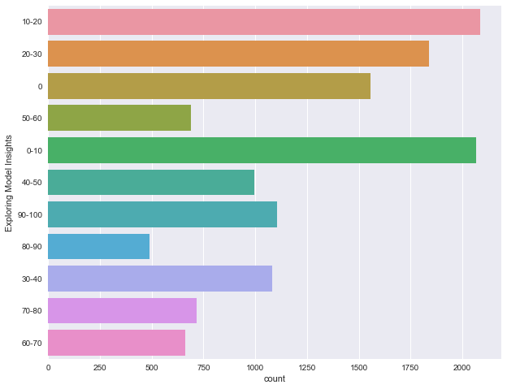

```python
generate_horizontal_countplot(y=exploringModelInsightsDF.exploringModelInsights,
                             figSize=(10,8),
                             ylabel = 'Exploring Model Insights',
                             figName = 'exploringModelInsights.jpeg')
```

We will persist the clean copy of the dataframe as a CSV file.

We no longer need "exploringModelInsightsDF" in the analysis. We will clean up from memory.

```python
exploringModelInsightsDF.to_csv('exploringModelInsights.csv',index=False)
```

```python
del exploringModelInsightsDF
gc.collect()
```

```
3238
```

### What methods do you prefer for explaining and/or interpreting decisions that are made by ML models?

- **Examine individual model coefficients**
- **Examine feature correlations**
- **Examine feature importances**
- **Plot decision boundaries**
- **Create partial dependence plots**
- **Dimensionality reduction techniques**
- **Attention mapping/saliency mapping**
- **Plot predicted vs. actual results**
- **Print out a decision tree**
- **Sensitivity analysis/perturbation importance**
- **LIME functions**
- **ELI5 functions**
- **SHAP functions**
- **None/I do not use these model explanation techniques**
- **Other**

```python
interpretingMLDF = multipleChoiceDF[['Q47_Part_1', 'Q47_Part_2','Q47_Part_3', 'Q47_Part_4','Q47_Part_5', 'Q47_Part_6',
                                     'Q47_Part_7','Q47_Part_8','Q47_Part_9','Q47_Part_10','Q47_Part_11','Q47_Part_12',
                                     'Q47_Part_13','Q47_Part_14','Q47_Part_15']]
```

```python
interpretingMLDF.head()
```

|  | Q47_Part_1 | Q47_Part_2 | Q47_Part_3 | Q47_Part_4 | Q47_Part_5 | Q47_Part_6 | Q47_Part_7 | Q47_Part_8 | Q47_Part_9 | Q47_Part_10 | Q47_Part_11 | Q47_Part_12 | Q47_Part_13 | Q47_Part_14 | Q47_Part_15 |
| --- | --- | --- | --- | --- | --- | --- | --- | --- | --- | --- | --- | --- | --- | --- | --- |
| 0 | What methods do you prefer for explaining and/... | What methods do you prefer for explaining and/... | What methods do you prefer for explaining and/... | What methods do you prefer for explaining and/... | What methods do you prefer for explaining and/... | What methods do you prefer for explaining and/... | What methods do you prefer for explaining and/... | What methods do you prefer for explaining and/... | What methods do you prefer for explaining and/... | What methods do you prefer for explaining and/... | What methods do you prefer for explaining and/... | What methods do you prefer for explaining and/... | What methods do you prefer for explaining and/... | What methods do you prefer for explaining and/... | What methods do you prefer for explaining and/... |
| 1 | NaN | NaN | NaN | NaN | NaN | NaN | NaN | NaN | NaN | NaN | NaN | NaN | NaN | NaN | NaN |
| 2 | NaN | NaN | NaN | NaN | NaN | NaN | NaN | NaN | NaN | NaN | NaN | NaN | NaN | NaN | NaN |
| 3 | NaN | Examine feature correlations | Examine feature importances | NaN | NaN | NaN | NaN | Plot predicted vs. actual results | NaN | NaN | NaN | NaN | NaN | NaN | NaN |
| 4 | NaN | Examine feature correlations | Examine feature importances | Plot decision boundaries | NaN | NaN | NaN | Plot predicted vs. actual results | NaN | Sensitivity analysis/perturbation importance | NaN | NaN | NaN | NaN | NaN |

```python
interpretingMLDF.info()
```

```
<class 'pandas.core.frame.DataFrame'>
RangeIndex: 23860 entries, 0 to 23859
Data columns (total 15 columns):
Q47_Part_1     3609 non-null object
Q47_Part_2     5418 non-null object
Q47_Part_3     6000 non-null object
Q47_Part_4     3502 non-null object
Q47_Part_5     1872 non-null object
Q47_Part_6     4355 non-null object
Q47_Part_7     1001 non-null object
Q47_Part_8     7605 non-null object
Q47_Part_9     3640 non-null object
Q47_Part_10    3102 non-null object
Q47_Part_11    926 non-null object
Q47_Part_12    523 non-null object
Q47_Part_13    737 non-null object
Q47_Part_14    2068 non-null object
Q47_Part_15    245 non-null object
dtypes: object(15)
memory usage: 2.7+ MB
```

From the visual and programmatic analysis:

- There are rows with missing data, but deviating from data we explored till now, missing information is expected per record as selections are optional. We will melt into one single column removing missing values, and use this column for analysis.
- All columns are loaded with the correct data type.
- Row with ID 0, is the same as the question. We will drop this row from the analysis as it does not have any empirical value.
- Column names are not informative, we will rename columns with more informative names.

```python
interpretingMLDF.drop([0],inplace=True)
interpretingMLDF.reset_index(drop = True, inplace=True)
```

```python
interpretingMLDF = pd.melt(interpretingMLDF)
```

```python
interpretingMLDF.head()
```

|  | variable | value |
| --- | --- | --- |
| 0 | Q47_Part_1 | NaN |
| 1 | Q47_Part_1 | NaN |
| 2 | Q47_Part_1 | NaN |
| 3 | Q47_Part_1 | NaN |
| 4 | Q47_Part_1 | NaN |

```python
interpretingMLDF.drop(columns=['variable'],inplace=True)
interpretingMLDF.rename(columns={"value":"interpretingML"},inplace=True)
interpretingMLDF.dropna(inplace=True)
interpretingMLDF.reset_index(drop=True,inplace=True)
```

```python
interpretingMLDF.head()
```

|  | interpretingML |
| --- | --- |
| 0 | Examine individual model coefficients |
| 1 | Examine individual model coefficients |
| 2 | Examine individual model coefficients |
| 3 | Examine individual model coefficients |
| 4 | Examine individual model coefficients |

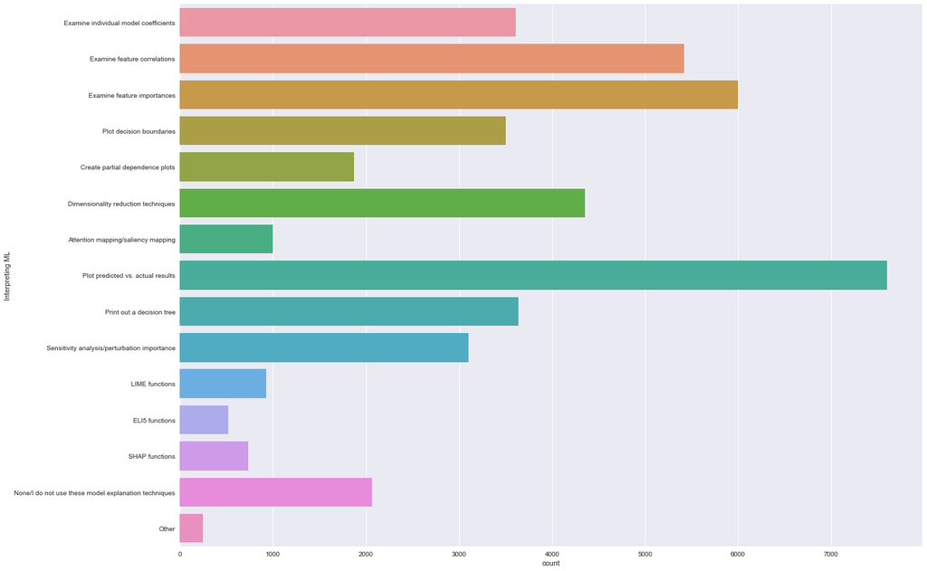

```python
generate_horizontal_countplot(y=interpretingMLDF.interpretingML,
                             figSize=(20,15),
                             ylabel = 'Interpreting ML',
                             figName = 'interpretingML.jpeg')
```

We will persist the clean copy of the dataframe as a CSV file.

We no longer need "interpretingMLDF" in the analysis. We will clean up from memory.

```python
interpretingMLDF.to_csv('interpretingML.csv',index=False)
```

```python
del interpretingMLDF
gc.collect()
```

```
3613
```

### Do you consider ML models to be "black boxes" with outputs that are difficult or impossible to explain?

```python
mlBlackBoxDF = pd.DataFrame(multipleChoiceDF.Q48)
```

```python
mlBlackBoxDF.head()
```

|  | Q48 |
| --- | --- |
| 0 | Do you consider ML models to be "black boxes" ... |
| 1 | NaN |
| 2 | NaN |
| 3 | I am confident that I can explain the outputs ... |
| 4 | Yes, most ML models are "black boxes" |

```python
mlBlackBoxDF.info()
```

```
<class 'pandas.core.frame.DataFrame'>
RangeIndex: 23860 entries, 0 to 23859
Data columns (total 1 columns):
Q48    13369 non-null object
dtypes: object(1)
memory usage: 186.5+ KB
```

From the visual and programmatic analysis:

- There are rows with missing data, we will not include these records in our report.
- All columns are loaded with the correct data type.
- Row with ID 0, is the same as the question. We will drop this row from the analysis as it does not have any empirical value.
- Column names are not informative, we will rename columns with more informative names.

```python
mlBlackBoxDF.drop([0],inplace=True)
mlBlackBoxDF.dropna(inplace=True)
mlBlackBoxDF.rename(columns={'Q48':'mlBlackBox'},inplace=True)
mlBlackBoxDF.reset_index(drop=True,inplace=True)
```

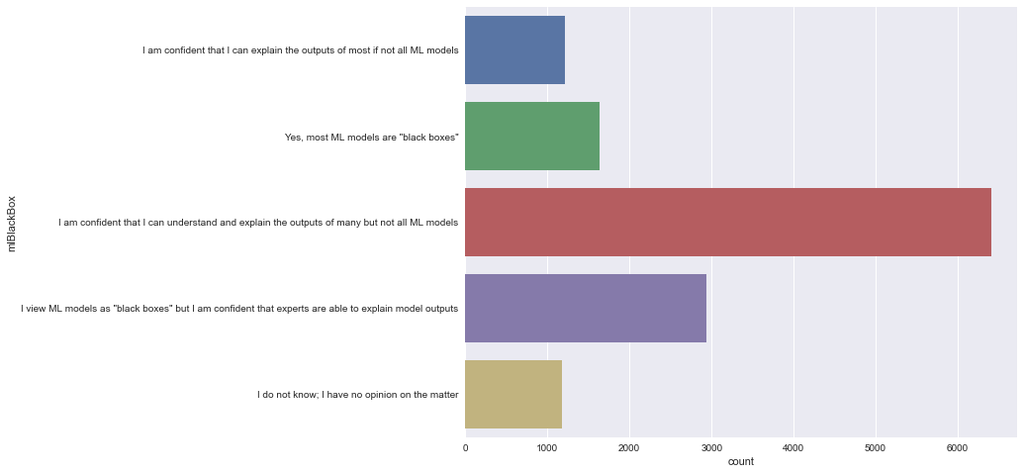

```python
generate_horizontal_countplot(y=mlBlackBoxDF.mlBlackBox,
                             figSize=(10,8),
                             ylabel = 'mlBlackBox',
                             figName = 'interpretingML.jpeg')
```

We will persist the clean copy of the dataframe as a CSV file.

We no longer need "mlBlackBoxDF" in the analysis. We will clean up from memory.

```python
mlBlackBoxDF.to_csv('mlBlackBox.csv',index=False)
```

```python
del mlBlackBoxDF
gc.collect()
```

```
2428
```

### What tools and methods do you use to make your work easy to reproduce?

- **Share code on Github or a similar code-sharing repository**
- **Share both data and code on Github or a similar code-sharing repository**
- **Share data, code, and environment using a hosted service (Kaggle Kernels, Google Colaboratory, Amazon SageMaker, etc.)**
- **Share data, code, and environment using containers (Docker, etc.)**
- **Share code, data, and environment using virtual machines (VirtualBox, etc.)**
- **Make sure the code is well documented**
- **Make sure the code is human-readable**
- **Define all random seeds**
- **Define relative rather than absolute file paths**
- **Include a text file describing all dependencies**
- **None/I do not make my work easy for others to reproduce**
- **Other**

```python
reproducingResultsDF = multipleChoiceDF[['Q49_Part_1', 'Q49_Part_2','Q49_Part_3', 'Q49_Part_4','Q49_Part_5',
                                         'Q49_Part_6','Q49_Part_7','Q49_Part_8','Q49_Part_9','Q49_Part_10',
                                         'Q49_Part_11','Q49_Part_12']]
```

```python
reproducingResultsDF.head()
```

|  | Q49_Part_1 | Q49_Part_2 | Q49_Part_3 | Q49_Part_4 | Q49_Part_5 | Q49_Part_6 | Q49_Part_7 | Q49_Part_8 | Q49_Part_9 | Q49_Part_10 | Q49_Part_11 | Q49_Part_12 |
| --- | --- | --- | --- | --- | --- | --- | --- | --- | --- | --- | --- | --- |
| 0 | What tools and methods do you use to make your... | What tools and methods do you use to make your... | What tools and methods do you use to make your... | What tools and methods do you use to make your... | What tools and methods do you use to make your... | What tools and methods do you use to make your... | What tools and methods do you use to make your... | What tools and methods do you use to make your... | What tools and methods do you use to make your... | What tools and methods do you use to make your... | What tools and methods do you use to make your... | What tools and methods do you use to make your... |
| 1 | NaN | NaN | NaN | NaN | NaN | NaN | NaN | NaN | NaN | NaN | NaN | NaN |
| 2 | NaN | NaN | NaN | NaN | NaN | NaN | NaN | NaN | NaN | NaN | NaN | NaN |
| 3 | NaN | NaN | NaN | NaN | NaN | NaN | Make sure the code is human-readable | Define all random seeds | NaN | Include a text file describing all dependencies | NaN | NaN |
| 4 | NaN | NaN | Share data, code, and environment using a host... | NaN | NaN | NaN | Make sure the code is human-readable | NaN | Define relative rather than absolute file paths | NaN | NaN | NaN |

```python
reproducingResultsDF.info()
```

```
<class 'pandas.core.frame.DataFrame'>
RangeIndex: 23860 entries, 0 to 23859
Data columns (total 12 columns):
Q49_Part_1     5637 non-null object
Q49_Part_2     4567 non-null object
Q49_Part_3     2946 non-null object
Q49_Part_4     2681 non-null object
Q49_Part_5     1478 non-null object
Q49_Part_6     8053 non-null object
Q49_Part_7     7782 non-null object
Q49_Part_8     4615 non-null object
Q49_Part_9     3666 non-null object
Q49_Part_10    4367 non-null object
Q49_Part_11    986 non-null object
Q49_Part_12    245 non-null object
dtypes: object(12)
memory usage: 2.2+ MB
```

From the visual and programmatic analysis:

- There are rows with missing data, but deviating from data we explored till now, missing information is expected per record as selections are optional. We will melt into one single column removing missing values, and use this column for analysis.
- All columns are loaded with the correct data type.
- Row with ID 0, is the same as the question. We will drop this row from the analysis as it does not have any empirical value.
- Column names are not informative, we will rename columns with more informative names.

```python
reproducingResultsDF.drop([0],inplace=True)
reproducingResultsDF.reset_index(drop=True,inplace=True)
```

```python
reproducingResultsDF.head()
```

|  | Q49_Part_1 | Q49_Part_2 | Q49_Part_3 | Q49_Part_4 | Q49_Part_5 | Q49_Part_6 | Q49_Part_7 | Q49_Part_8 | Q49_Part_9 | Q49_Part_10 | Q49_Part_11 | Q49_Part_12 |
| --- | --- | --- | --- | --- | --- | --- | --- | --- | --- | --- | --- | --- |
| 0 | NaN | NaN | NaN | NaN | NaN | NaN | NaN | NaN | NaN | NaN | NaN | NaN |
| 1 | NaN | NaN | NaN | NaN | NaN | NaN | NaN | NaN | NaN | NaN | NaN | NaN |
| 2 | NaN | NaN | NaN | NaN | NaN | NaN | Make sure the code is human-readable | Define all random seeds | NaN | Include a text file describing all dependencies | NaN | NaN |
| 3 | NaN | NaN | Share data, code, and environment using a host... | NaN | NaN | NaN | Make sure the code is human-readable | NaN | Define relative rather than absolute file paths | NaN | NaN | NaN |
| 4 | NaN | NaN | NaN | NaN | NaN | NaN | NaN | NaN | Define relative rather than absolute file paths | NaN | NaN | NaN |

```python
reproducingResultsDF = pd.melt(reproducingResultsDF)
```

```python
reproducingResultsDF.head()
```

|  | variable | value |
| --- | --- | --- |
| 0 | Q49_Part_1 | NaN |
| 1 | Q49_Part_1 | NaN |
| 2 | Q49_Part_1 | NaN |
| 3 | Q49_Part_1 | NaN |
| 4 | Q49_Part_1 | NaN |

```python
reproducingResultsDF.drop(columns=['variable'],inplace=True)
reproducingResultsDF.rename(columns={'value':'reproducingResults'},inplace=True)
reproducingResultsDF.dropna(inplace=True)
reproducingResultsDF.reset_index(drop=True,inplace=True)
```

**Reproducibility is paramount for successful ML model. Once the model is tuned, it must produce the same result as long as the input is constant irrespective of the machine in which it is executed. Tools and methods mentioned in the figure below are used to make your work accessible and easy to reproduce.**

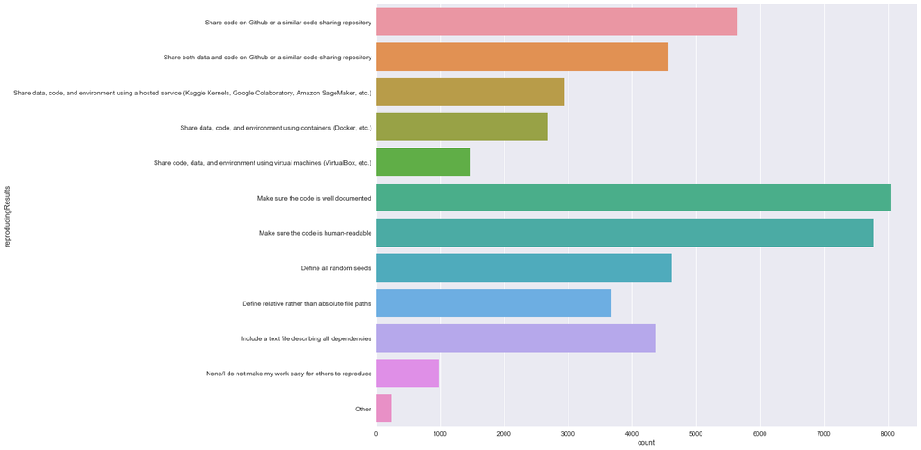

```python
generate_horizontal_countplot(y=reproducingResultsDF.reproducingResults,
                             figSize=(15,12),
                             ylabel = 'reproducingResults',
                             figName = 'reproducingResults.jpeg')
```

We will persist the clean copy of the dataframe as a CSV file.

We no longer need "reproducingResultsDF" in the analysis. We will clean up from memory.

```python
reproducingResultsDF.to_csv('reproducingResults.csv',index=False)
```

```python
del reproducingResultsDF
gc.collect()
```

```
3356
```

### What barriers prevent you from making your work even easier to reuse and reproduce?

- **Too expensive**
- **Too time-consuming**
- **Requires too much technical knowledge**
- **Afraid that others will use my work without giving proper credit**
- **Not enough incentives to share my work**
- **I had never considered making my work easier for others to reproduce**
- **None of these reasons apply to me**
- **Other**

```python
barriersToReproduceDF = multipleChoiceDF[['Q50_Part_1', 'Q50_Part_2','Q50_Part_3', 'Q50_Part_4','Q50_Part_5',
                                        'Q50_Part_6','Q50_Part_7','Q50_Part_8']]
```

```python
barriersToReproduceDF.head()
```

|  | Q50_Part_1 | Q50_Part_2 | Q50_Part_3 | Q50_Part_4 | Q50_Part_5 | Q50_Part_6 | Q50_Part_7 | Q50_Part_8 |
| --- | --- | --- | --- | --- | --- | --- | --- | --- |
| 0 | What barriers prevent you from making your wor... | What barriers prevent you from making your wor... | What barriers prevent you from making your wor... | What barriers prevent you from making your wor... | What barriers prevent you from making your wor... | What barriers prevent you from making your wor... | What barriers prevent you from making your wor... | What barriers prevent you from making your wor... |
| 1 | NaN | NaN | NaN | NaN | NaN | NaN | NaN | NaN |
| 2 | NaN | NaN | NaN | NaN | NaN | NaN | NaN | NaN |
| 3 | NaN | Too time-consuming | NaN | NaN | NaN | NaN | NaN | NaN |
| 4 | NaN | NaN | Requires too much technical knowledge | NaN | Not enough incentives to share my work | NaN | NaN | NaN |

```python
barriersToReproduceDF.info()
```

```
<class 'pandas.core.frame.DataFrame'>
RangeIndex: 23860 entries, 0 to 23859
Data columns (total 8 columns):
Q50_Part_1    1372 non-null object
Q50_Part_2    6479 non-null object
Q50_Part_3    2675 non-null object
Q50_Part_4    2105 non-null object
Q50_Part_5    3570 non-null object
Q50_Part_6    1060 non-null object
Q50_Part_7    2501 non-null object
Q50_Part_8    521 non-null object
dtypes: object(8)
memory usage: 1.5+ MB
```

From the visual and programmatic analysis:

- There are rows with missing data, but deviating from data we explored till now, missing information is expected per record as selections are optional. We will melt into one single column removing missing values, and use this column for analysis.
- All columns are loaded with the correct data type.
- Row with ID 0, is the same as the question. We will drop this row from the analysis as it does not have any empirical value.
- Column names are not informative, we will rename columns with more informative names.

```python
barriersToReproduceDF.drop([0],inplace=True)
barriersToReproduceDF.reset_index(drop=True,inplace=True)
```

```python
barriersToReproduceDF = pd.melt(barriersToReproduceDF)
```

```python
barriersToReproduceDF.head()
```

|  | variable | value |
| --- | --- | --- |
| 0 | Q50_Part_1 | NaN |
| 1 | Q50_Part_1 | NaN |
| 2 | Q50_Part_1 | NaN |
| 3 | Q50_Part_1 | NaN |
| 4 | Q50_Part_1 | NaN |

```python
barriersToReproduceDF.drop(columns=['variable'],inplace=True)
barriersToReproduceDF.rename(columns={'value':'barriersToReproduce'},inplace = True)
barriersToReproduceDF.dropna(inplace=True)
barriersToReproduceDF.reset_index(drop=True,inplace=True)
```

```python
barriersToReproduceDF.head()
```

|  | barriersToReproduce |
| --- | --- |
| 0 | Too expensive |
| 1 | Too expensive |
| 2 | Too expensive |
| 3 | Too expensive |
| 4 | Too expensive |

**One of the advantages of ML models is the output of one model can be used as input for another model, creating a pipeline of models.**

**Notably, in the case of deep learning, this is very advantageous. When developing an image recognization algorithm by utilizing trained layers, we can save a lot of time and computation power.**

**Respondents were asked what are the barriers preventing them from making their work more accessible to reuse and reproduce.**

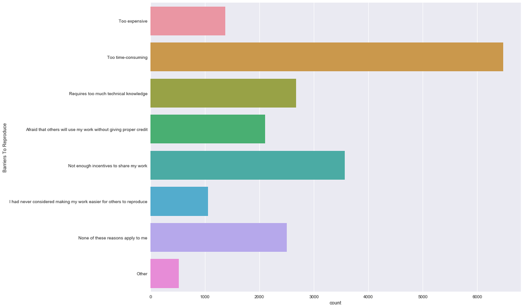

```python
generate_horizontal_countplot(y=barriersToReproduceDF.barriersToReproduce,
                             figSize=(15,12),
                             ylabel = 'Barriers To Reproduce',
                             figName = 'barriersToReproduce.jpeg')
```

```python
barriersToReproduceDF.to_csv('barriersToReproduce.csv',index=False)
```

### Conclusion

In this notebook, we have analyzed various metrics that were used to measure the quality of Machine learning and Data science projects.